# Ornek Teorisi

### Reklama Harcaması Optimşzasyonu

Çeşitli mecralara reklam veriliyor.Reklamların tıklanma ve geri dönüşüm oranları optimize edilmeye çalışılıyor. Buna yönelik çeşitli senaryolarla reklama tıklanma olasılıkları hesaplanmak isteniyor. AMAÇ:Optimum şekilde Bütçemi kullanıp maksimum geri dönüş alayım.

```python
from scipy.stats import binom
```

```python
p=0.01 #başarı olasılık değerim
n=100 #deneme sayım
rv= binom(100,0.01)
print(rv.pmf(1)) # bu reklamı 1 kişi görme olasılığı
print(rv.pmf(5))
print(rv.pmf(10))
```

```
0.36972963764971983
0.0028977871237616114
7.006035693977161e-08
```

### Poisson dağılımı (Poisson Distribution)

Belli bir aralıkta(zaman, alan, hacim, uzunluk…) meydana gelen nadir olayların sayısı Poisson dağılır. For example, The number of cases of a disease in different towns The number of mutations in set sized regions of a chromosome.

lambda bekelenen sonucun ortalama gerçekleşme sayısıdır yani ortalamadı. X:olayın ortaya çıkma sayısı nadir olay. X: İlgilenilen olayların verilen aralıkta meydana gelme sayısı

X ~ Poisson(λ)

lamda hem varyansı hem ortalamayı temsil eder.

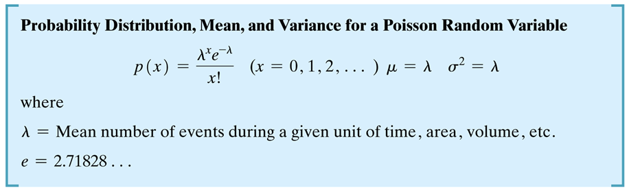

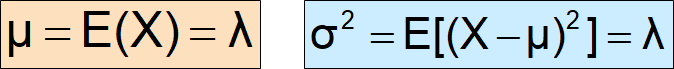

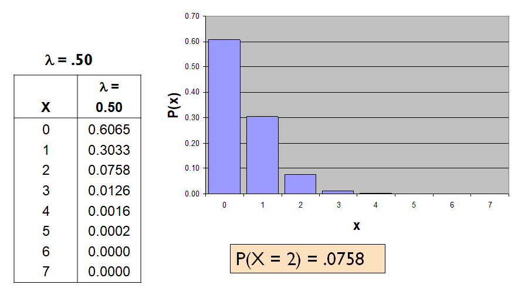

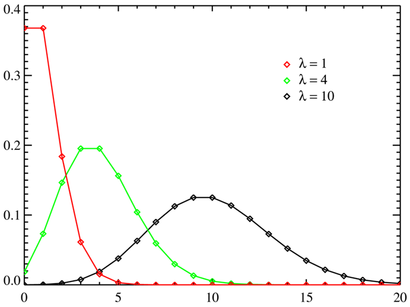

```python
n büyük ve p olasılık değeri küçük olmalıdır.Poisson olması için .
n*p<5 ise nadir olay denir.
n>50 olmalıdır.
```

# Ornekk

Hatalı ilan girişi olasılıkları hesaplanmak isteniyor.

Detaylar:

[output not shown]

```python
from scipy.stats import poisson
lamda_=0.1
rv=poisson(mu=lamda_)
```

```python
print(rv.pmf(k=1)) #1 hata olması
```

```
0.09048374180359597
```

```python
print(rv.pmf(k=5))
```

```
7.54031181696634e-08
```

```python
print(rv.pmf(k=10))
```

```
2.493489357462418e-17
```

### Normal Distribution

Normal dağıldığı bilinen sürekli rassal değişkenler için olasılık hesaplanmasında kullanılır.

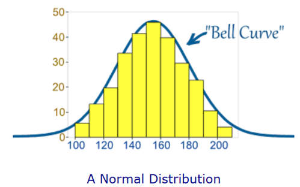

The normal curve is symmetrical about its mean μ. The mean, median and mode are equal to each other. Total area under the curve is equal to 1.

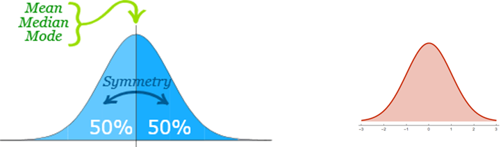

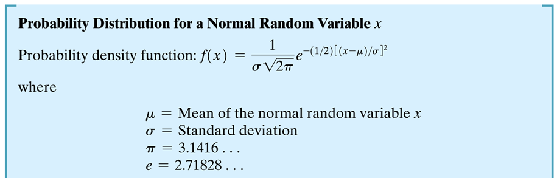

Parametreler değişirse:

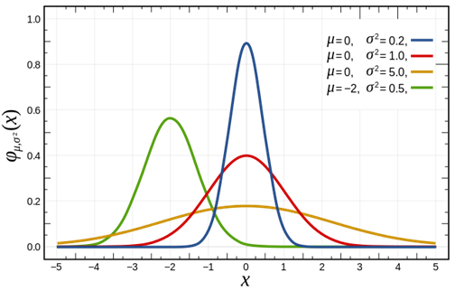

Basıklık ölçüsü için referans değer, Normal dağılımın basıklık değeri olan 3’tür.

Basıklık ölçüsü için referans değer, Normal dağılımın basıklık değeri olan 3’tür.

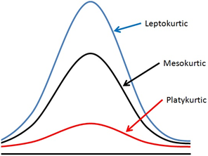

Problem: Ürün satış olasılıklarının hesaplanması

```
Bir toplantı öncesinde gelecek ay ile ilgili satışlarrın belirli değerlerde gerçekleşmesi olasılıkları belirlenmek isteniyor.
```

Detaylar: Dağılımın normal olduğu biliniyor.

```
Aylık ortalama satış sayısı 80K ,standart sapma 5 K

90 K dan fazla satış yapma olasılığı nedir
```

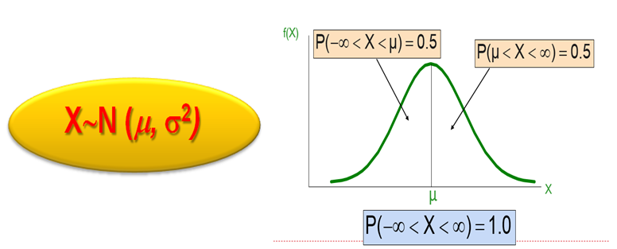

```python
from scipy.stats import norm
```

```python
# 90 K dan fazla satış yapma olasılığı nedir

1-norm.cdf(90,80,5)
```

```
0.02275013194817921
```

```python
#73 K dan fazla satış yapma olasılığı nedir
1-norm.cdf(73,80,5)
```

```
0.9192433407662289
```

```python
#73 K den az olması olasılığı
norm.cdf(73,80,5)
```

```
0.08075665923377107
```

```python
#85 K ile 90 K arasında olma olasılığı
norm.cdf(90,80,5)-norm.cdf(85,80,5)
```

```
0.13590512198327787
```

```python
### Normallik Sınaması (Assessing Normality )
Normallik sınaması, verilerin normal dağılıp dağılmadığına karar verme sürecidir.

 Normal dağılan bir kitleden çekilen bir örneklem her zaman normal dağılmayabilir.


Örneklemler her seferinde değiştiğinden , her örneklemin dağılımı da değişir.

İstatistiksel testler, küçük veri setleri için (n<30) kullanıldığında, kitlenin normal ya da normale yakın dağılım gösterdiği varsayımı yapılır. Küçük veri setlerinin histogramları kitlenin dağılımını her zaman yansıtmayabilir. Bu sebeple, kitlenin normalliğini sınamak için farklı yöntemlere ihtiyaç duyulmaktadır.

Bununla birlikte, örneklem normal dağılan bir kitleden geliyor ve yeterli büyüklüğe sahip ise, dağılımı normale yakın olabilir
```

```python
### Normallik Sınaması için Kullanılan Yöntemler
*Histogram

*Boxplot

*Normal Quantile Plot (Normal Olasılık Grafiği)

*(Normal probability Plot))

*Uyum İyiliği Testleri (Goodness of Fit Tests)
```

[output not shown]

### Uyum İyiliği Testleri (Goodness of Fit Tests)

Ampirik Dağılım Fonksiyonuna Dayalı Testler:

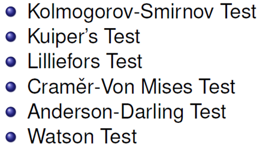

### Regresyon ve Korelasyona Dayalı Testler:

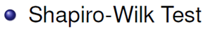

- Normallik sınamasında , Histogram ve Box plot yanında, sıklıkla kullanılan diğer bir grafik yöntem ise

"Normal Probability Plot",

"Normal Quantile Plot"

"Normal Q-Q Plot"

Bu grafik, değişkenlerin gözlenen değerleri ile beklenen standart normal dağılan gözlem değerlerini karşılaştırır. Başka bir deyişle, herbir gözlem değeri ile teorik olarak normal dağılan formunun doğrusal bir yapıda olup olmadığını gösterir.

### The Normal Probability Plot

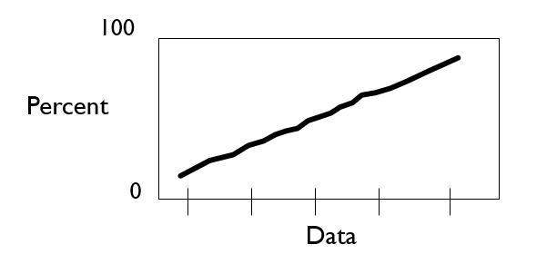

Rİgth skewed plot,left skewed plot and uniform

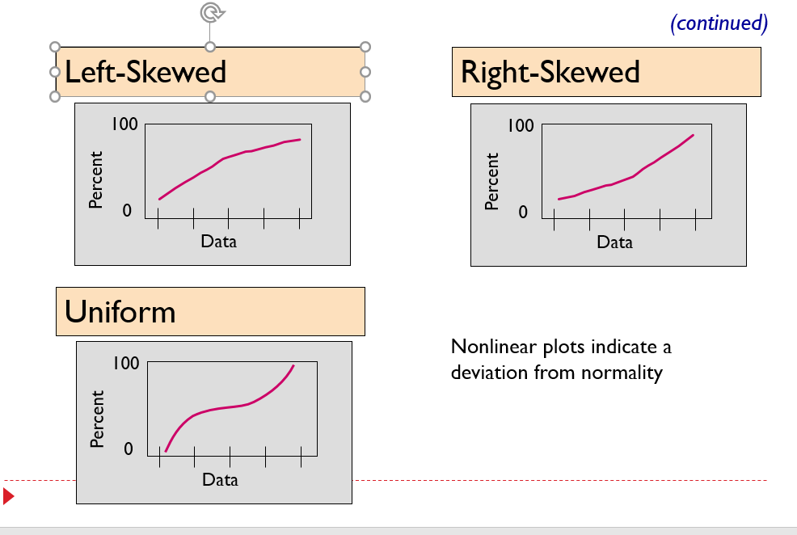

# Hipotez Tipleri:

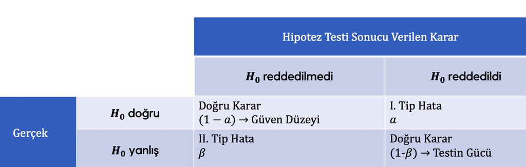

# p-value

p-value değeri <0.05 çıksın isteriz H0 reddedilsin isteriz ancak dağılımları test ederken H0 reddetmek istemeyiz(shapiro wilk brcuhe pegan testleri vs ho reddedilemeze var mak isteriz ama katsayıların anlamlaılıklarını test ederken ho reddedilmek istenir.)

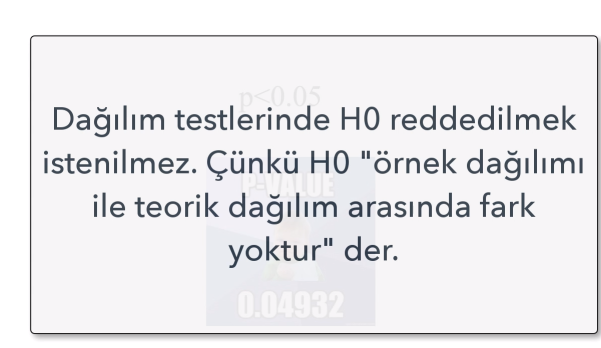

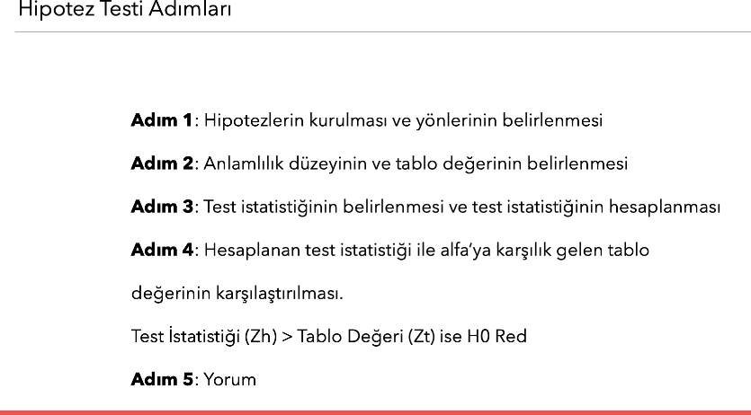

# T örneklem testi

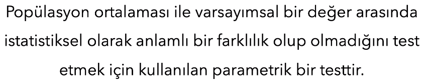

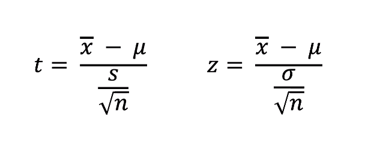

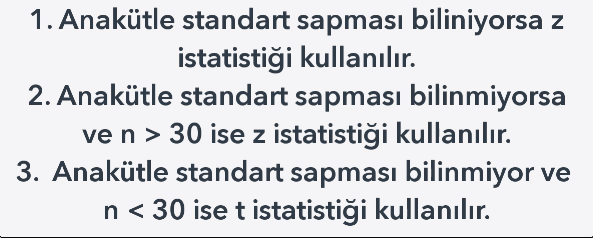

Varsayımlar : Normal dağılımdır .tek örnekleö t-testi tek örneklemin ortalamasına ilişkin test apma ihtiyacı olduğunda kullanılan testtir.

### Web Sİtesinde Geçirilen Süre Optimizasyonu

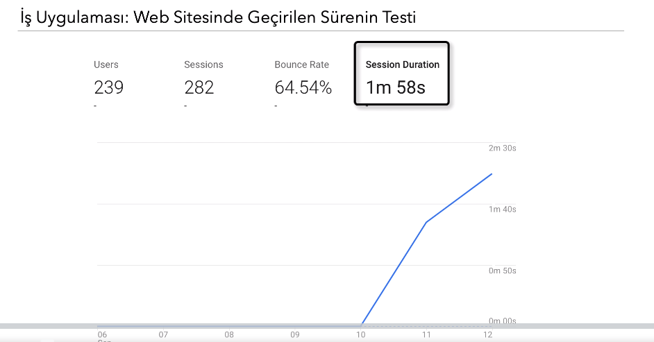

problem:Web sitesinde geçirilen ortalama süre gerçekten 118 saniye mi?

Hipotez:

H0=118

H1!=118

```python
import numpy as np

olcumler = np.array([17, 160, 234, 149, 145, 107, 197, 75, 201, 225, 211, 119,
              157, 145, 127, 244, 163, 114, 145,  65, 112, 185, 202, 146,
              203, 224, 203, 114, 188, 156, 187, 154, 177, 95, 165, 50, 110,
              216, 138, 151, 166, 135, 155, 84, 251, 173, 131, 207, 121, 120])
```

**Test İstatistiği:**

${\displaystyle t={\frac {{\bar {x}}-\mu _{0}}{\frac {s}{\sqrt {n}}}}}$

```python
olcumler[0:10]
```

```
array([ 17, 160, 234, 149, 145, 107, 197,  75, 201, 225])
```

```python
import scipy.stats as stats
stats.describe(olcumler)
```

```
DescribeResult(nobs=50, minmax=(17, 251), mean=154.38, variance=2578.0363265306123, skewness=-0.32398897278694483, kurtosis=-0.05849823498415985)
```

- €mean =154,38 şansa bağlı olabilir test yapıcaz. * #### varsayımlar

#### 1-Histogram

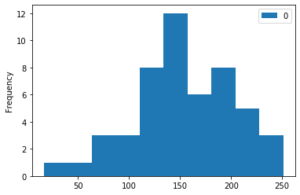

```python
import pandas as pd
import matplotlib.pyplot as plt
pd.DataFrame(olcumler).plot.hist()
```